# MAVE QC Report

2023-07-13

## 1. Introduction

MAVEQC is a flexible R-package that provides QC analysis of Saturation Genome Editing (SGE) experimental data. Available under GPL 3.0 from https://github.com/wtsi-hgi/MAVEQC

## 2. Screen QC

Displays QC plots and statistics for all samples for QC.

### 2.1. Sample Sheet

| sample_name | library_independent_count | library_dependent_count | valiant_meta | vep_anno | adapt5 | adapt3 | library_name | library_type |
| --- | --- | --- | --- | --- | --- | --- | --- | --- |
| hgsm3_d0_r1 | Rep1_HGSM3_Day0.allcounts.tsv.gz | Rep1_HGSM3_Day0.libcounts.tsv.gz | meta.csv.gz | meta_consequences.tsv.gz | CTGACTGGCACCTCTTCCCCCAGGA | CCCCGACCCCTCCCCAGCGTGAATG | SMARCA4_exon26 | screen |
| hgsm3_d4_r1 | Rep1_HGSM3_Day4.allcounts.tsv.gz | Rep1_HGSM3_Day4.libcounts.tsv.gz | meta.csv.gz | meta_consequences.tsv.gz | CTGACTGGCACCTCTTCCCCCAGGA | CCCCGACCCCTCCCCAGCGTGAATG | SMARCA4_exon26 | screen |
| hgsm3_d7_r1 | Rep1_HGSM3_Day7.allcounts.tsv.gz | Rep1_HGSM3_Day7.libcounts.tsv.gz | meta.csv.gz | meta_consequences.tsv.gz | CTGACTGGCACCTCTTCCCCCAGGA | CCCCGACCCCTCCCCAGCGTGAATG | SMARCA4_exon26 | screen |
| hgsm3_d15_r1 | Rep1_HGSM3_Day15.allcounts.tsv.gz | Rep1_HGSM3_Day15.libcounts.tsv.gz | meta.csv.gz | meta_consequences.tsv.gz | CTGACTGGCACCTCTTCCCCCAGGA | CCCCGACCCCTCCCCAGCGTGAATG | SMARCA4_exon26 | screen |
| hgsm3_d4_r2 | Rep2_HGSM3_Day4.allcounts.tsv.gz | Rep2_HGSM3_Day4.libcounts.tsv.gz | meta.csv.gz | meta_consequences.tsv.gz | CTGACTGGCACCTCTTCCCCCAGGA | CCCCGACCCCTCCCCAGCGTGAATG | SMARCA4_exon26 | screen |
| hgsm3_d7_r2 | Rep2_HGSM3_Day7.allcounts.tsv.gz | Rep2_HGSM3_Day7.libcounts.tsv.gz | meta.csv.gz | meta_consequences.tsv.gz | CTGACTGGCACCTCTTCCCCCAGGA | CCCCGACCCCTCCCCAGCGTGAATG | SMARCA4_exon26 | screen |
| hgsm3_d15_r2 | Rep2_HGSM3_Day15.allcounts.tsv.gz | Rep2_HGSM3_Day15.libcounts.tsv.gz | meta.csv.gz | meta_consequences.tsv.gz | CTGACTGGCACCTCTTCCCCCAGGA | CCCCGACCCCTCCCCAGCGTGAATG | SMARCA4_exon26 | screen |
| hgsm3_d4_r3 | Rep3_HGSM3_Day4.allcounts.tsv.gz | Rep3_HGSM3_Day4.libcounts.tsv.gz | meta.csv.gz | meta_consequences.tsv.gz | CTGACTGGCACCTCTTCCCCCAGGA | CCCCGACCCCTCCCCAGCGTGAATG | SMARCA4_exon26 | screen |
| hgsm3_d7_r3 | Rep3_HGSM3_Day7.allcounts.tsv.gz | Rep3_HGSM3_Day7.libcounts.tsv.gz | meta.csv.gz | meta_consequences.tsv.gz | CTGACTGGCACCTCTTCCCCCAGGA | CCCCGACCCCTCCCCAGCGTGAATG | SMARCA4_exon26 | screen |
| hgsm3_d15_r3 | Rep3_HGSM3_Day15.allcounts.tsv.gz | Rep3_HGSM3_Day15.libcounts.tsv.gz | meta.csv.gz | meta_consequences.tsv.gz | CTGACTGGCACCTCTTCCCCCAGGA | CCCCGACCCCTCCCCAGCGTGAATG | SMARCA4_exon26 | screen |

### 2.2. Run Sample QC

#### 2.2.1. Read Length Distrubtion

Displays the percentage of reads for each sample, based on 50 nucleotide increments.

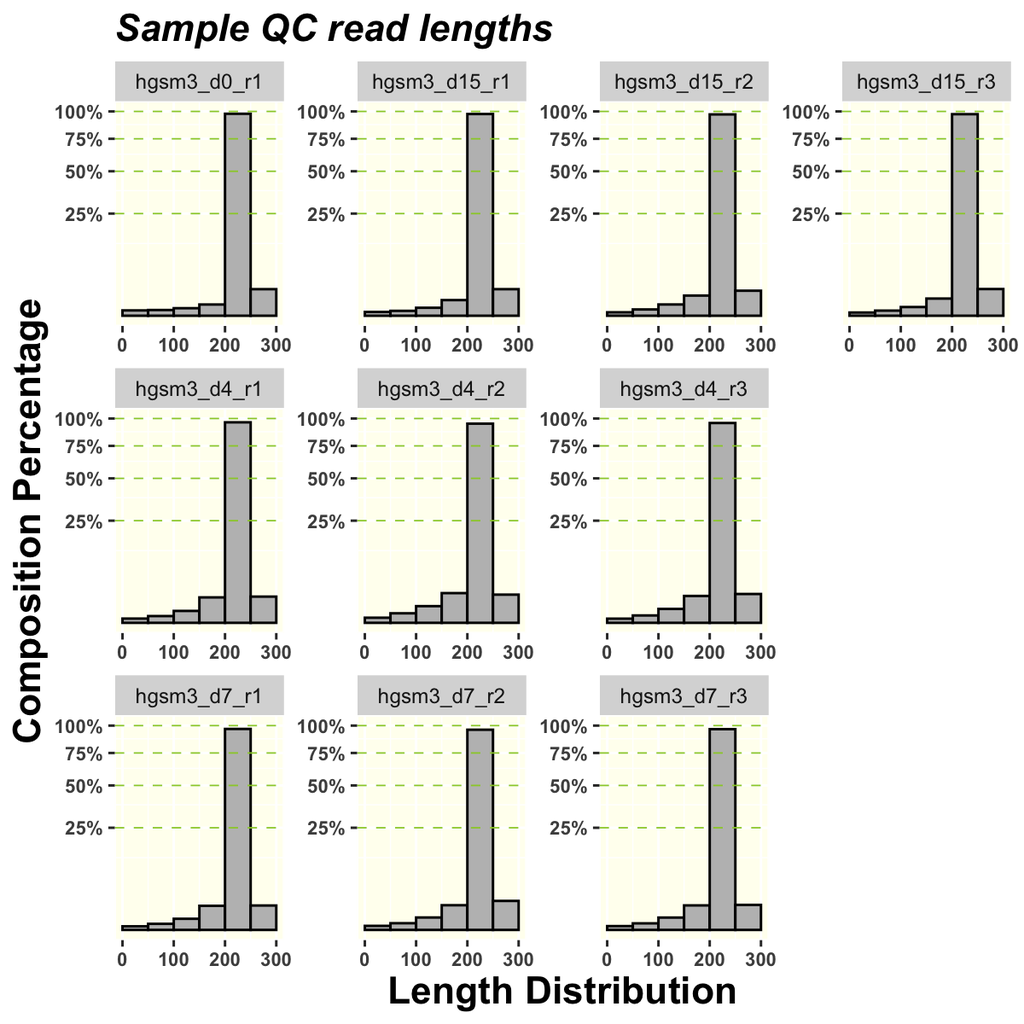

| Group | Sample | Total Reads | % 0 ~ 50 | % 50 ~ 100 | % 100 ~ 150 | % 150 ~ 200 | % 200 ~ 250 | % 250 ~ 300 | Pass Threshold | Pass |
| --- | --- | --- | --- | --- | --- | --- | --- | --- | --- | --- |
| SMARCA4_exon26 | hgsm3_d0_r1 | 4049537 | 0.1 | 0.1 | 0.1 | 0.3 | 97.7 | 1.7 | 90 | True |
| SMARCA4_exon26 | hgsm3_d4_r1 | 5077590 | 0 | 0.1 | 0.3 | 1.5 | 96.3 | 1.6 | 90 | True |
| SMARCA4_exon26 | hgsm3_d7_r1 | 4379641 | 0 | 0.1 | 0.3 | 1.4 | 96.8 | 1.4 | 90 | True |
| SMARCA4_exon26 | hgsm3_d15_r1 | 4397054 | 0 | 0.1 | 0.2 | 0.6 | 97.5 | 1.7 | 90 | True |
| SMARCA4_exon26 | hgsm3_d4_r2 | 4496558 | 0.1 | 0.2 | 0.7 | 2.1 | 95 | 1.9 | 90 | True |
| SMARCA4_exon26 | hgsm3_d7_r2 | 4771374 | 0 | 0.1 | 0.4 | 1.5 | 96 | 2 | 90 | True |
| SMARCA4_exon26 | hgsm3_d15_r2 | 4348304 | 0 | 0.1 | 0.3 | 1 | 97.1 | 1.5 | 90 | True |
| SMARCA4_exon26 | hgsm3_d4_r3 | 4122574 | 0 | 0.1 | 0.5 | 1.7 | 95.6 | 2 | 90 | True |
| SMARCA4_exon26 | hgsm3_d7_r3 | 3261754 | 0 | 0.1 | 0.4 | 1.4 | 96.6 | 1.5 | 90 | True |
| SMARCA4_exon26 | hgsm3_d15_r3 | 4642374 | 0 | 0.1 | 0.2 | 0.7 | 97.3 | 1.7 | 90 | True |

#### 2.2.2. Total Reads

Displays the total number of reads per sample. Filtering based on 1-dimensional Kmean clustering that excludes unique sequences with low read counts.

- **Accepted reads**: Total read count for all unique sequences with sufficient reads.
- **Excluded reads**: Total read count for all unique sequences with insufficient reads.

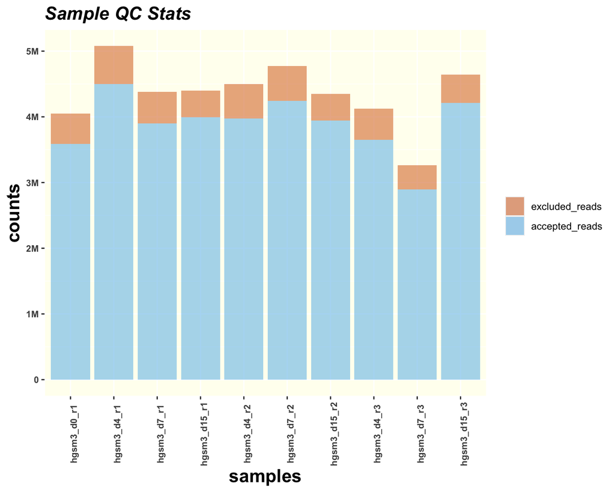

| Group | Sample | Accepted Reads | % Accepted Reads | Excluded Reads | % Excluded Reads | Total Reads | Pass Threshold | Pass |
| --- | --- | --- | --- | --- | --- | --- | --- | --- |
| SMARCA4_exon26 | hgsm3_d0_r1 | 3589530 | 88.6 | 460007 | 11.4 | 4049537 | 1000000 | True |
| SMARCA4_exon26 | hgsm3_d4_r1 | 4496504 | 88.6 | 581086 | 11.4 | 5077590 | 1000000 | True |
| SMARCA4_exon26 | hgsm3_d7_r1 | 3900428 | 89.1 | 479213 | 10.9 | 4379641 | 1000000 | True |
| SMARCA4_exon26 | hgsm3_d15_r1 | 3992091 | 90.8 | 404963 | 9.2 | 4397054 | 1000000 | True |
| SMARCA4_exon26 | hgsm3_d4_r2 | 3972764 | 88.4 | 523794 | 11.6 | 4496558 | 1000000 | True |
| SMARCA4_exon26 | hgsm3_d7_r2 | 4244348 | 89 | 527026 | 11 | 4771374 | 1000000 | True |
| SMARCA4_exon26 | hgsm3_d15_r2 | 3941284 | 90.6 | 407020 | 9.4 | 4348304 | 1000000 | True |
| SMARCA4_exon26 | hgsm3_d4_r3 | 3652879 | 88.6 | 469695 | 11.4 | 4122574 | 1000000 | True |
| SMARCA4_exon26 | hgsm3_d7_r3 | 2898426 | 88.9 | 363328 | 11.1 | 3261754 | 1000000 | True |
| SMARCA4_exon26 | hgsm3_d15_r3 | 4210818 | 90.7 | 431556 | 9.3 | 4642374 | 1000000 | True |

#### 2.2.3. Accepted Reads

Displays the percentage of library reads vs non-library reads (ie. Reference, PAM and Unmapped) for Accepted Reads.

- **Library Reads**: Percentage reads mapping to template oligo sequences, including intended variants.
- **Reference Reads**: Percentage reads mapping to Reference.
- **PAM_Reads**: Percentage reads mapping to PAM/Protospacer Protection Edits (PPEs), without intended variant.
- **Unmapped Reads**: Percentage of Unmapped Reads.

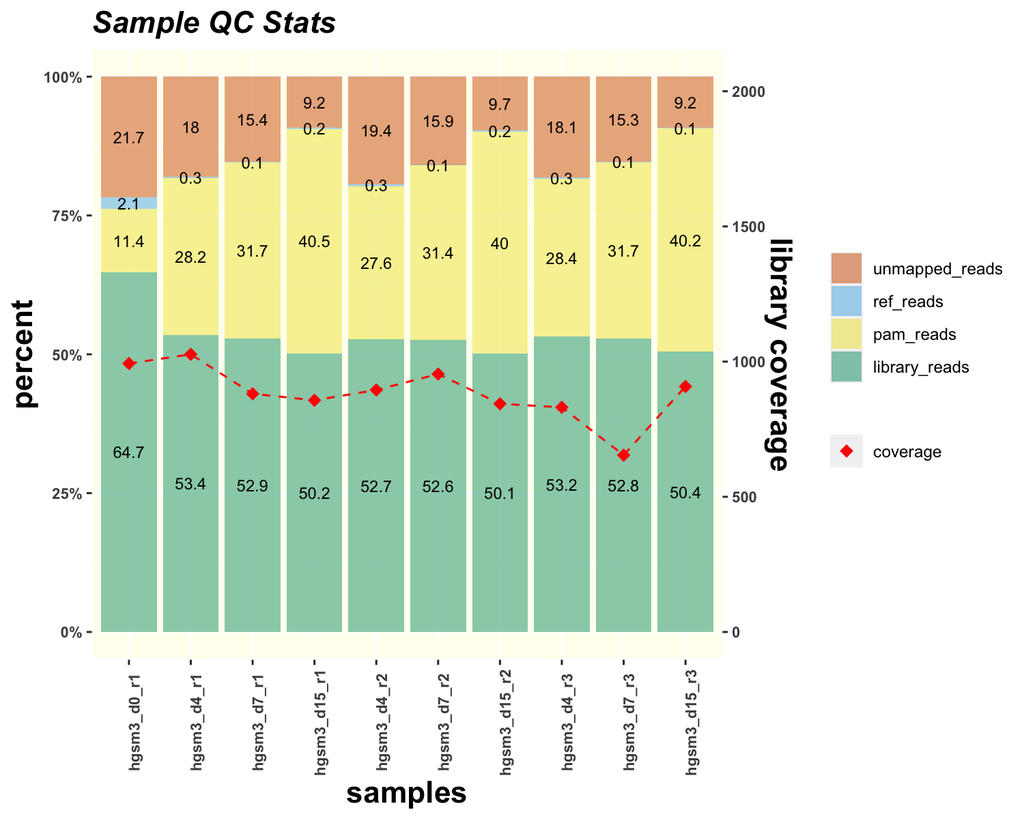

| Group | Sample | % Library Reads | % Reference Reads | % PAM Reads | % Unmapped Reads | Pass Threshold | Pass |
| --- | --- | --- | --- | --- | --- | --- | --- |
| SMARCA4_exon26 | hgsm3_d0_r1 | 64.7 | 2.1 | 11.4 | 21.7 | 40 | True |
| SMARCA4_exon26 | hgsm3_d4_r1 | 53.4 | 0.3 | 28.2 | 18 | 40 | True |
| SMARCA4_exon26 | hgsm3_d7_r1 | 52.9 | 0.1 | 31.7 | 15.4 | 40 | True |
| SMARCA4_exon26 | hgsm3_d15_r1 | 50.2 | 0.2 | 40.5 | 9.2 | 40 | True |
| SMARCA4_exon26 | hgsm3_d4_r2 | 52.7 | 0.3 | 27.6 | 19.4 | 40 | True |
| SMARCA4_exon26 | hgsm3_d7_r2 | 52.6 | 0.1 | 31.4 | 15.9 | 40 | True |
| SMARCA4_exon26 | hgsm3_d15_r2 | 50.1 | 0.2 | 40 | 9.7 | 40 | True |
| SMARCA4_exon26 | hgsm3_d4_r3 | 53.2 | 0.3 | 28.4 | 18.1 | 40 | True |
| SMARCA4_exon26 | hgsm3_d7_r3 | 52.8 | 0.1 | 31.7 | 15.3 | 40 | True |
| SMARCA4_exon26 | hgsm3_d15_r3 | 50.4 | 0.1 | 40.2 | 9.2 | 40 | True |

Defines the mean read count per template oligo sequence.

| Group | Sample | Total Library Reads | Total Template Oligo Sequences | Library Coverage | Pass Threshold | Pass |
| --- | --- | --- | --- | --- | --- | --- |
| SMARCA4_exon26 | hgsm3_d0_r1 | 2321699 | 2338 | 993 | 100 | True |
| SMARCA4_exon26 | hgsm3_d4_r1 | 2402820 | 2338 | 1027 | 100 | True |
| SMARCA4_exon26 | hgsm3_d7_r1 | 2061566 | 2338 | 881 | 100 | True |
| SMARCA4_exon26 | hgsm3_d15_r1 | 2003930 | 2338 | 857 | 100 | True |
| SMARCA4_exon26 | hgsm3_d4_r2 | 2093257 | 2338 | 895 | 100 | True |
| SMARCA4_exon26 | hgsm3_d7_r2 | 2232509 | 2338 | 954 | 100 | True |
| SMARCA4_exon26 | hgsm3_d15_r2 | 1973483 | 2338 | 844 | 100 | True |
| SMARCA4_exon26 | hgsm3_d4_r3 | 1943008 | 2338 | 831 | 100 | True |
| SMARCA4_exon26 | hgsm3_d7_r3 | 1531065 | 2338 | 654 | 100 | True |
| SMARCA4_exon26 | hgsm3_d15_r3 | 2124172 | 2338 | 908 | 100 | True |

#### 2.2.4. Genomic Coverage

Distribution of variants across targeton region based on log2(count+1) values.

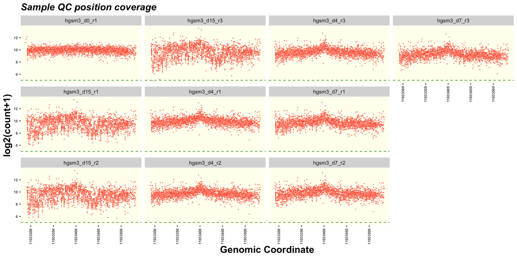

| Group | Sample | Chromosome | Strand | Genomic Start | Genomic End | % Low Abundance | Low Abundance cutoff | Pass Threshold | Pass |
| --- | --- | --- | --- | --- | --- | --- | --- | --- | --- |
| SMARCA4_exon26 | hgsm3_d0_r1 | chr19 | + | 11033267 | 11033558 | 0 | 5 | 30 | True |
| SMARCA4_exon26 | hgsm3_d4_r1 | chr19 | + | 11033267 | 11033558 | 0 | 5 | 30 | True |
| SMARCA4_exon26 | hgsm3_d7_r1 | chr19 | + | 11033267 | 11033558 | 0 | 5 | 30 | True |
| SMARCA4_exon26 | hgsm3_d15_r1 | chr19 | + | 11033267 | 11033558 | 0 | 5 | 30 | True |
| SMARCA4_exon26 | hgsm3_d4_r2 | chr19 | + | 11033267 | 11033558 | 0 | 5 | 30 | True |
| SMARCA4_exon26 | hgsm3_d7_r2 | chr19 | + | 11033267 | 11033558 | 0 | 5 | 30 | True |
| SMARCA4_exon26 | hgsm3_d15_r2 | chr19 | + | 11033267 | 11033558 | 0 | 5 | 30 | True |
| SMARCA4_exon26 | hgsm3_d4_r3 | chr19 | + | 11033267 | 11033558 | 0 | 5 | 30 | True |
| SMARCA4_exon26 | hgsm3_d7_r3 | chr19 | + | 11033267 | 11033558 | 0 | 5 | 30 | True |
| SMARCA4_exon26 | hgsm3_d15_r3 | chr19 | + | 11033267 | 11033558 | 0 | 5 | 30 | True |

#### 2.2.5. Genomic Position Percentage

Displays distribution of “LOF” (loss-of-function) vs all “Other” variants across the targeton region, based on read percentages for reference timepoint. Requires concordant distribution of LOF and Other variants.

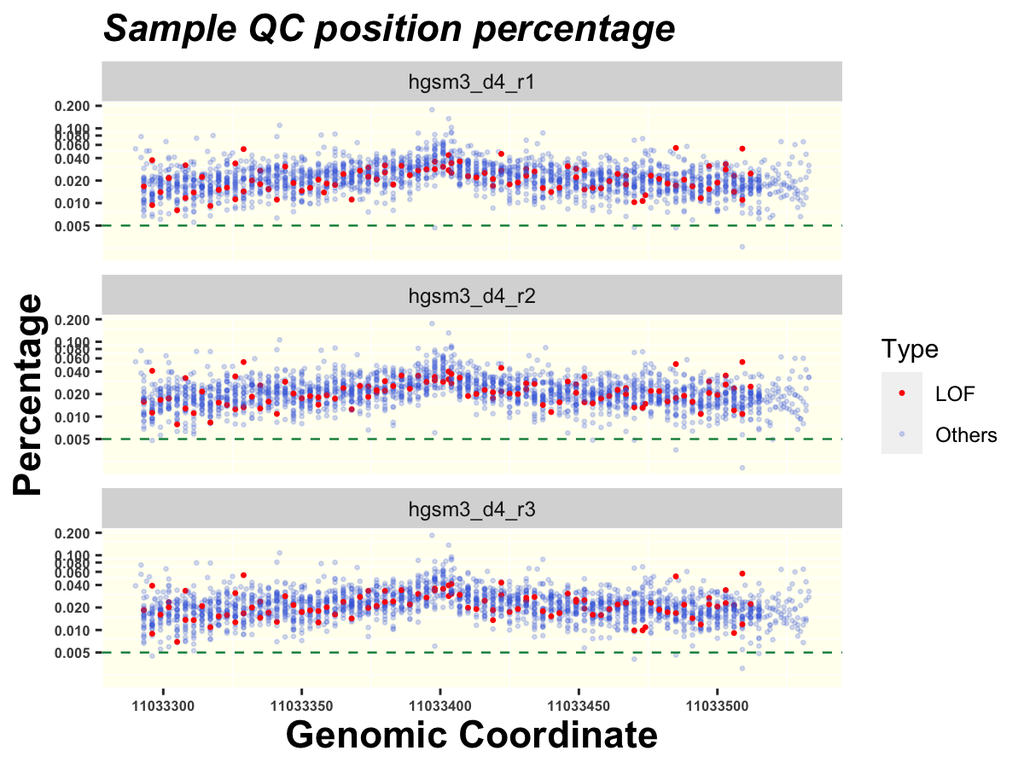

| Group | Sample | Chromosome | Strand | Genomic Start | Genomic End | % Low Abundance (LOF) | % Low Abundance (Others) | % Low Abundance (ALL) | % Low Abundance cutoff | Pass Threshold | Pass |
| --- | --- | --- | --- | --- | --- | --- | --- | --- | --- | --- | --- |
| SMARCA4_exon26 | hgsm3_d0_r1 | chr19 | + | 11033267 | 11033558 | 0 | 0 | 0 | 0.005 | 30 | True |
| SMARCA4_exon26 | hgsm3_d4_r1 | chr19 | + | 11033267 | 11033558 | 0 | 0.2 | 0.2 | 0.005 | 30 | True |
| SMARCA4_exon26 | hgsm3_d7_r1 | chr19 | + | 11033267 | 11033558 | 0 | 0.2 | 0.2 | 0.005 | 30 | True |
| SMARCA4_exon26 | hgsm3_d15_r1 | chr19 | + | 11033267 | 11033558 | 0.2 | 4.7 | 4.9 | 0.005 | 30 | True |
| SMARCA4_exon26 | hgsm3_d4_r2 | chr19 | + | 11033267 | 11033558 | 0 | 0.2 | 0.2 | 0.005 | 30 | True |
| SMARCA4_exon26 | hgsm3_d7_r2 | chr19 | + | 11033267 | 11033558 | 0 | 0.2 | 0.2 | 0.005 | 30 | True |
| SMARCA4_exon26 | hgsm3_d15_r2 | chr19 | + | 11033267 | 11033558 | 0.2 | 4.7 | 4.9 | 0.005 | 30 | True |
| SMARCA4_exon26 | hgsm3_d4_r3 | chr19 | + | 11033267 | 11033558 | 0 | 0.2 | 0.2 | 0.005 | 30 | True |
| SMARCA4_exon26 | hgsm3_d7_r3 | chr19 | + | 11033267 | 11033558 | 0 | 0.3 | 0.3 | 0.005 | 30 | True |
| SMARCA4_exon26 | hgsm3_d15_r3 | chr19 | + | 11033267 | 11033558 | 0.4 | 4.7 | 5.1 | 0.005 | 30 | True |

### 2.3. Run Experiment QC

#### 2.3.1. Sample Correlations

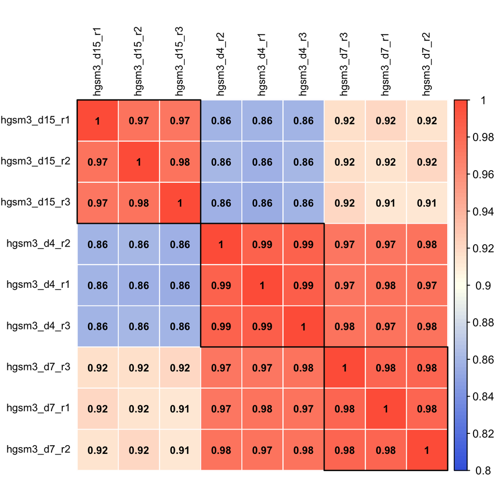

#### 2.3.2. Sample PCA

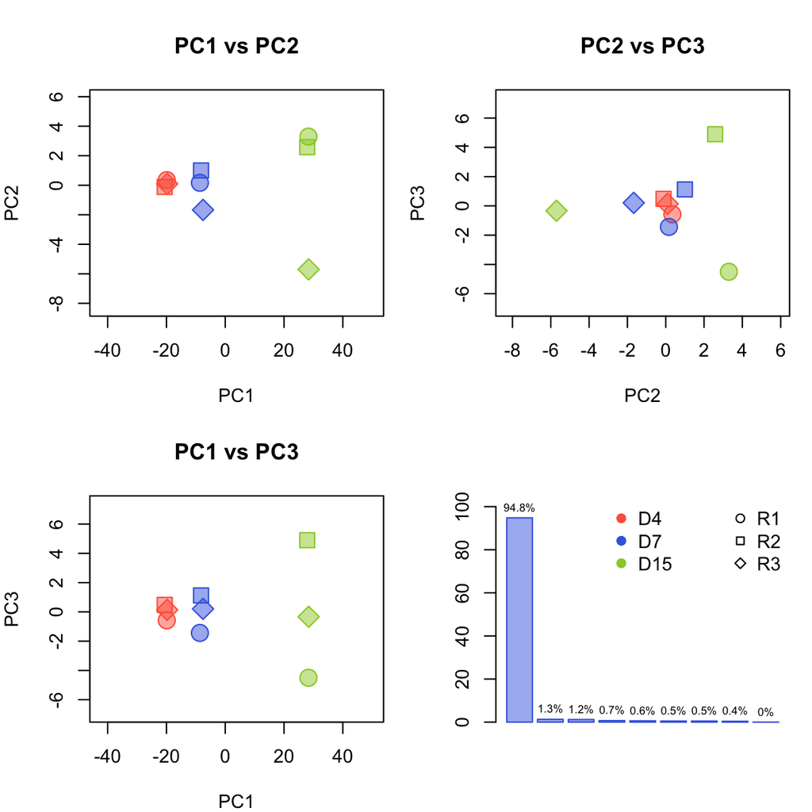

#### 2.3.3. Folder Change

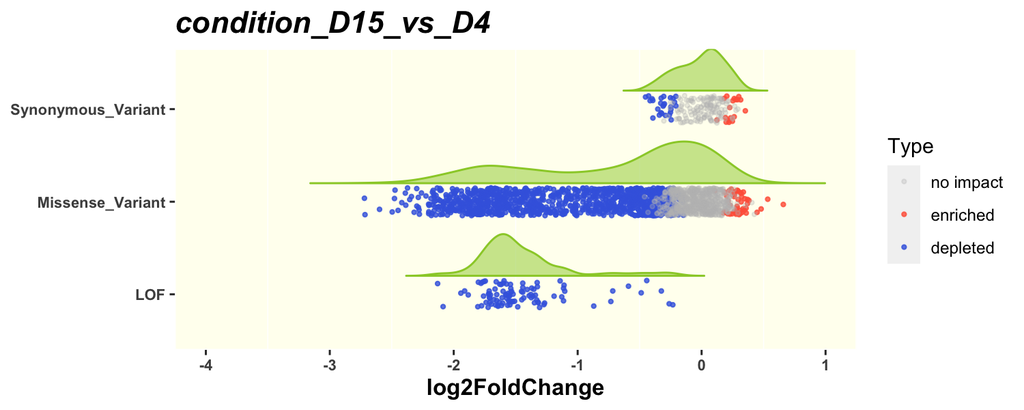

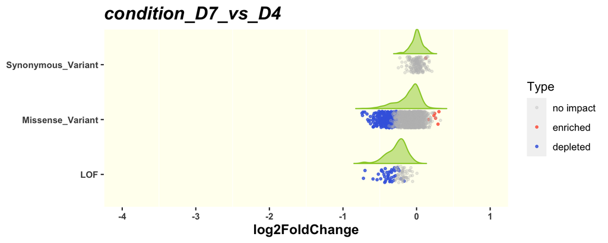